# Pipelining with muPipeR

*February 22, 2016*

## Installation and set up

`muPipeR` can be directly installed from [github](https://github.com/MPIIComputationalEpigenetics/muPipeR)

```r
library(devtools)
install_github("MPIIComputationalEpigenetics/muPipeR")
```

## Preliminaries

```r
# library(epiRepeatR)
library(devtools)
setwd("~/BroadSVN/eclipse_workspace/muPipeR")
load_all("muPipeR")
```

Setting the analysis directory

```r
# anaDir <- "~/tmp_work/muPipeR_test"
anaDir <- file.path(tempdir(), "muPipeR_test")
```

## Pipelines

### Setting up the pipeline

Create the pipeline object

```r
pipe <- PipR(anaDir)
```

Note that the analysis directory must be non-existing. Creating a `PipR` object will create the analysis directory with its subdirectories:

| directory | description |
| --- | --- |
| `results` | Contains the results of the analysis. For each analysis step, a subdirectory will be created that contains the results of that particular step. |
| `log` | Contains log files for the analysis jobs that are run. |
| `status` | Contains status information on the analysis. |
| `temp` | Contains temporary files. |

Add an analysis step. Here, we simply create an empty input file

```r
pipe <- addStep(pipe,
  "create_input_01",
  "touch",
  args="${STEPDIR}/input01.txt"
)
```

The following variables will be replaced in argument strings

| variable | description |
| --- | --- |
| `${STEPDIR}` | result directory of the given analysis step |
| `${STEPDIR:stepname}` | result directory of a specific analysis step with name `stepname` |

Add an analysis step with multiple jobs. Here, we create 5 additional empty files

```r
pipe <- addStep(pipe,
  "create_input_multiple",
  rep("touch", 5),
  args=lapply(LETTERS[1:5], FUN=function(x){paste0("${STEPDIR}/input", x, ".txt")})
)
```

The next step takes an input file and appends a string to obtain its output file. This step depends to the input step to be successfully completed. This can be specified in the `parents` argument.

```r
# a shell script for appending a string to a file
appendTool <- system.file(file.path("extdata", "examples", "appendLine.sh"), package="muPipeR")
pipe <- addStep(pipe,
  "append_01",
  appendTool,
  args=c(
    "${STEPDIR:create_input_01}/input01.txt",
    "${STEPDIR}/output01.txt",
    "'appended line 01'"
  ),
  parents="create_input_01"
)
# add a step appending a line to each of the input files
# create a list of arguments
aa <- lapply(1:5, FUN=function(i){
  c(
    paste0("${STEPDIR:create_input_multiple}/input", LETTERS[i], ".txt"),
    paste0("${STEPDIR}/output", LETTERS[i], ".txt"),
    paste0("'appended line ", LETTERS[i], "'")
  )
})
pipe <- addStep(pipe,
  "append_multiple",
  appendTool,
  args=aa,
  parents="create_input_multiple"
)
```

Add an analysis step combining the output from multiple steps:

```r
# a shell script for concatenating multiple files (2nd to nth argument)
# into one output file (1st argument)
concatFilesTool <- system.file(file.path("extdata", "examples", "concatFiles.sh"), package="muPipeR")
pipe <- addStep(pipe,
  "join_01_ABC",
  concatFilesTool,
  args=c(
    "${STEPDIR}/concat_01ABC.txt",
    "${STEPDIR:append_01}/output01.txt",
    "${STEPDIR:append_multiple}/outputA.txt",
    "${STEPDIR:append_multiple}/outputB.txt",
    "${STEPDIR:append_multiple}/outputC.txt"
  ),
  parents=c("append_01", "append_multiple")
)
```

### Inspecting the pipeline

Show the pipeline graph

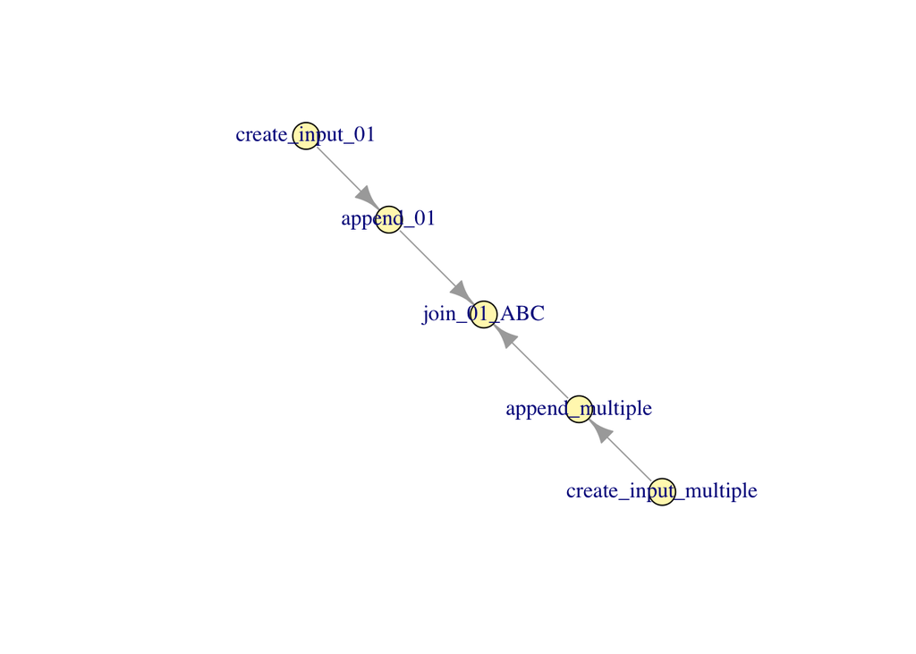

```r
plotGraph(pipe)
```

### Running the pipeline

All steps in the pipeline are executed using the `run` command:

```r
pipe <- run(pipe)
```

```
## 2016-02-22 15:49:17     0.4    INFO Dependend jobs are not supported during execution by CommandRsystem. --> Assuming dependencies have already completed
## 2016-02-22 15:49:17     0.4  STATUS Executing step: create_input_01
```

```
## 2016-02-22 15:49:17     0.4  STATUS Executing step: append_01
```

```
## 2016-02-22 15:49:17     0.4  STATUS Executing step: create_input_multiple
```

```
## 2016-02-22 15:49:18     0.4  STATUS Executing step: append_multiple
```

```
## 2016-02-22 15:49:18     0.4  STATUS Executing step: join_01_ABC
```

In the output object, the steps are marked as completed (e.g. they are green in the graph):

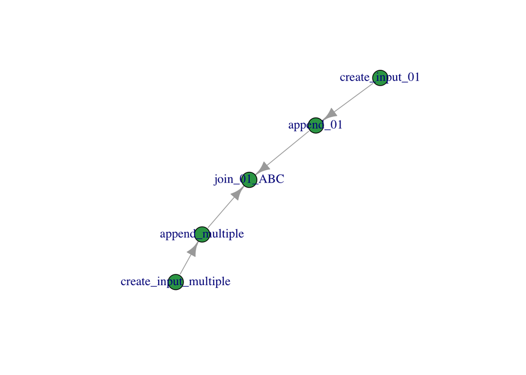

```r
plotGraph(pipe)
```

### Resetting pipeline steps

Undo/reset a pipeline step and its dependent steps:

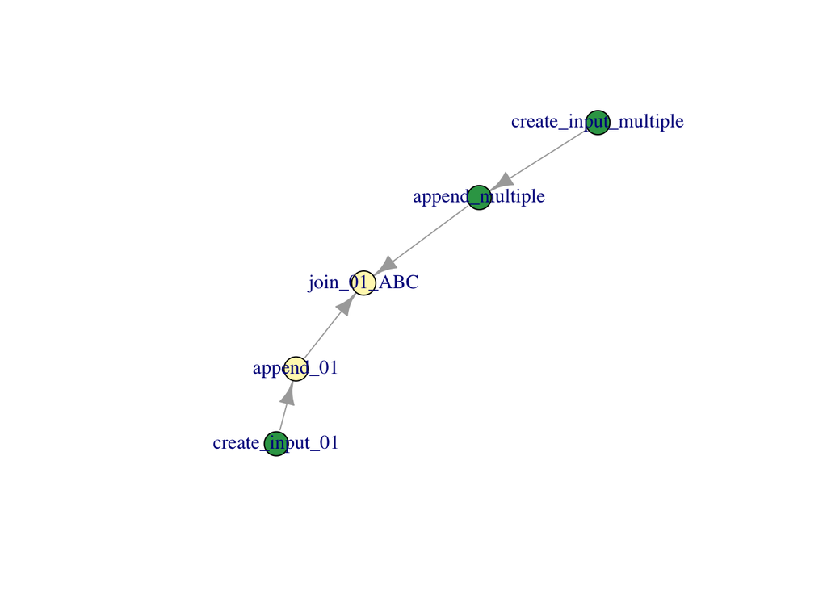

```r
pipe <- resetStep(pipe, "append_01")
plotGraph(pipe)
```

Per default this will also delete the corresponding subdirectories in the result directory. If you run the pipeline again, the reset steps will be run again:

```r
pipe <- run(pipe)
```

```
## 2016-02-22 15:49:19     0.4    INFO Dependend jobs are not supported during execution by CommandRsystem. --> Assuming dependencies have already completed
## 2016-02-22 15:49:19     0.4  STATUS Skipping already completed step: create_input_01
## 2016-02-22 15:49:19     0.4  STATUS Executing step: append_01
```

```
## 2016-02-22 15:49:19     0.4  STATUS Skipping already completed step: create_input_multiple
## 2016-02-22 15:49:19     0.4  STATUS Skipping already completed step: append_multiple
## 2016-02-22 15:49:20     0.4  STATUS Executing step: join_01_ABC
```

### Cleaning up

To remove temporary files and empty log files use:

```r
cleanup(pipe)
```

## Running jobs using `CommandR` and its subclasses

The `CommandR` class is a virtual class implementing methods for running commands along with corresponding arguments. Currently there are two child classes implemented in the package:

[output not shown]

```r
cmdr <- CommandRsystem()
```

```
## 2016-02-22 15:49:20     0.4    INFO Dependend jobs are not supported during execution by CommandRsystem. --> Assuming dependencies have already completed
```

`CommandR` objects can also be initialized with a logging directory where the output of the commands is written to:

```r
cmdr <- CommandRsystem(logDir=tempdir())
```

```
## 2016-02-22 15:49:20     0.4    INFO Dependend jobs are not supported during execution by CommandRsystem. --> Assuming dependencies have already completed
```

Note, that for `CommandRsge` objects, it is mandatory to specify a logging directory that can be accessed by all execution nodes in the SGE queue.

Get the logging directory:

```r
getLogDir(cmdr)
```

```
## [1] "/var/folders/f_/39551bz958304cj4852hxcx00000gn/T//Rtmpp1vzQD"
```

In order to run a command with a `CommandR`, it has to be packaged into a `Job` object.

```r
echoJob <- Job("echo", args="'Hello!'")
```

If you want to identify a job later, it might also be useful to name it:

```r
echoJob <- Job("echo", args="'Hello!'", id="say_hello")
```

You can access the command that will be executed, it’s arguments and other job details:

```r
getId(echoJob)
```

```
## [1] "say_hello"
```

```r
getCmd(echoJob)
```

```
## [1] "echo"
```

```r
getArgs(echoJob)
```

```
## [1] "'Hello!'"
```

```r
getCallString(echoJob)
```

```
## [1] "echo 'Hello!'"
```

The `exec` method can be used to actually execute jobs:

```r
jobRes <- exec(cmdr, echoJob)
```

If you want the output of a job to be stored in the result, use the `result` argument:

```r
jobRes <- exec(cmdr, echoJob, result=TRUE)
```

The result of the execution is an object of class `JobResult`, that contains information on the job’s output, errors and status:

```r
getOut(jobRes)
```

```
## [1] "Hello!"
```

```r
getStatus(jobRes)
```

```
## [1] 0
```

```r
getErr(jobRes)
```

```
## character(0)
```

You can also execute an array of jobs using `lexec` (list execute):

```r
echoJobList <- lapply(1:5, FUN=function(i){
  Job("echo", args=paste0("'Hello ", i, "!'"), id=paste0("say_hello_", i))
})
jobResList <- lexec(cmdr, echoJobList)
```

If you want to specify that a job depends on other jobs you can add them using the `dependsOn` argument:

```r
echoJob2 <- Job("echo", args="'I mean: Hello, my name is HAL2000.'",
                id="say_hello_2", dependsOn=list(echoJob))
```

author: *Fabian Müller* <fmueller@mpi-inf.mpg.de>